# Problem Statement: AllLife Credit Card Customer Segmentation

## Objective

- To identify different segments in the existing customer based on their spending patterns as well as past interaction with the bank.

### Attribute details

- Sl_No
- Customer Key
- Avg_Credit_Limit
- Total_Credit_Cards
- Total_visits_bank
- Total_visits_online
- Total_calls_made

```python
# Importing Necessary Library

import pandas as pd
import numpy as np
import seaborn as sns
import matplotlib.pyplot as plt

from sklearn import metrics

from sklearn.cluster import KMeans

from scipy.stats import zscore

%matplotlib inline
```

```python
# Reading Data File and printing first 5 rows of data to visualize data
df= pd.read_excel('Credit Card Customer Data.xlsx')
df.head()
```

|  | Sl_No | Customer Key | Avg_Credit_Limit | Total_Credit_Cards | Total_visits_bank | Total_visits_online | Total_calls_made |
| --- | --- | --- | --- | --- | --- | --- | --- |
| 0 | 1 | 87073 | 100000 | 2 | 1 | 1 | 0 |
| 1 | 2 | 38414 | 50000 | 3 | 0 | 10 | 9 |
| 2 | 3 | 17341 | 50000 | 7 | 1 | 3 | 4 |
| 3 | 4 | 40496 | 30000 | 5 | 1 | 1 | 4 |
| 4 | 5 | 47437 | 100000 | 6 | 0 | 12 | 3 |

```python
# Shape of Data
print('Shape of Data :',df.shape)
```

```
Shape of Data : (660, 7)
```

- There are 660 rows
- There are 7 attributes out of which Sl_No and Customer Key can be ignored

```python
# Data Types
df.dtypes
```

```
Sl_No                  int64
Customer Key           int64
Avg_Credit_Limit       int64
Total_Credit_Cards     int64
Total_visits_bank      int64
Total_visits_online    int64
Total_calls_made       int64
dtype: object
```

- All atributes are of Numerical/Integer type

```python
# Checking for Null Values in data
df.isnull().sum()
```

```
Sl_No                  0
Customer Key           0
Avg_Credit_Limit       0
Total_Credit_Cards     0
Total_visits_bank      0
Total_visits_online    0
Total_calls_made       0
dtype: int64
```

- There are no Null values in data

```python
# Checking for Skewness
df.skew(axis=0)
```

```
Sl_No                  0.000000
Customer Key           0.051462
Avg_Credit_Limit       2.202396
Total_Credit_Cards     0.144879
Total_visits_bank      0.141896
Total_visits_online    2.225607
Total_calls_made       0.658905
dtype: float64
```

- There is skewness in Avg_Credit_Limit and Total_visits_online

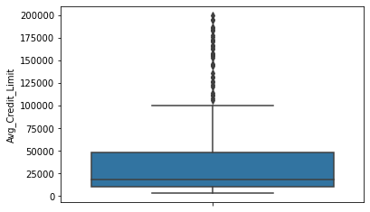

```python
sns.boxplot(y='Avg_Credit_Limit', data=df )
```

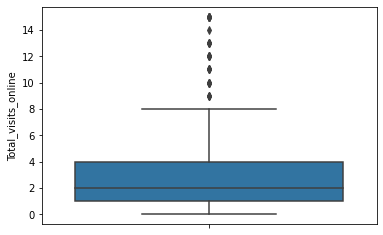

```python
sns.boxplot(y='Total_visits_online', data=df )
```

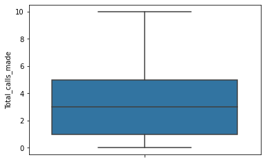

```python
sns.boxplot(y='Total_calls_made', data=df )
```

```python
# To describe Mean, Median and Quartile of Data Set
df.drop(columns=['Sl_No','Customer Key']).describe()
```

|  | Avg_Credit_Limit | Total_Credit_Cards | Total_visits_bank | Total_visits_online | Total_calls_made |
| --- | --- | --- | --- | --- | --- |
| count | 660.000000 | 660.000000 | 660.000000 | 660.000000 | 660.000000 |
| mean | 34574.242424 | 4.706061 | 2.403030 | 2.606061 | 3.583333 |
| std | 37625.487804 | 2.167835 | 1.631813 | 2.935724 | 2.865317 |
| min | 3000.000000 | 1.000000 | 0.000000 | 0.000000 | 0.000000 |
| 25% | 10000.000000 | 3.000000 | 1.000000 | 1.000000 | 1.000000 |
| 50% | 18000.000000 | 5.000000 | 2.000000 | 2.000000 | 3.000000 |
| 75% | 48000.000000 | 6.000000 | 4.000000 | 4.000000 | 5.000000 |
| max | 200000.000000 | 10.000000 | 5.000000 | 15.000000 | 10.000000 |

## Exploratory Data Analysis

#### Plotting Histogram of Data

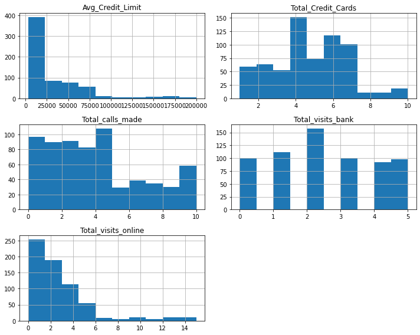

```python
# values in histogram

df[['Avg_Credit_Limit', 'Total_Credit_Cards','Total_visits_bank', 'Total_visits_online', 'Total_calls_made']].hist(figsize=(10,8))
plt.tight_layout()
```

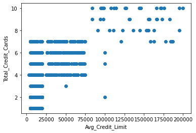

```python
plt.scatter(df['Avg_Credit_Limit'], df['Total_Credit_Cards'])
plt.xlabel('Avg_Credit_Limit')
plt.ylabel('Total_Credit_Cards')
```

- Customers having more Credit card have more Average Credit Limit

```python
df_Attr= df.drop(columns=['Sl_No','Customer Key'], axis=1)
df_Scaled=df_Attr.apply(zscore)
```

- Dropping not important attributes
- Scaling the data to make all columns data distribution equal

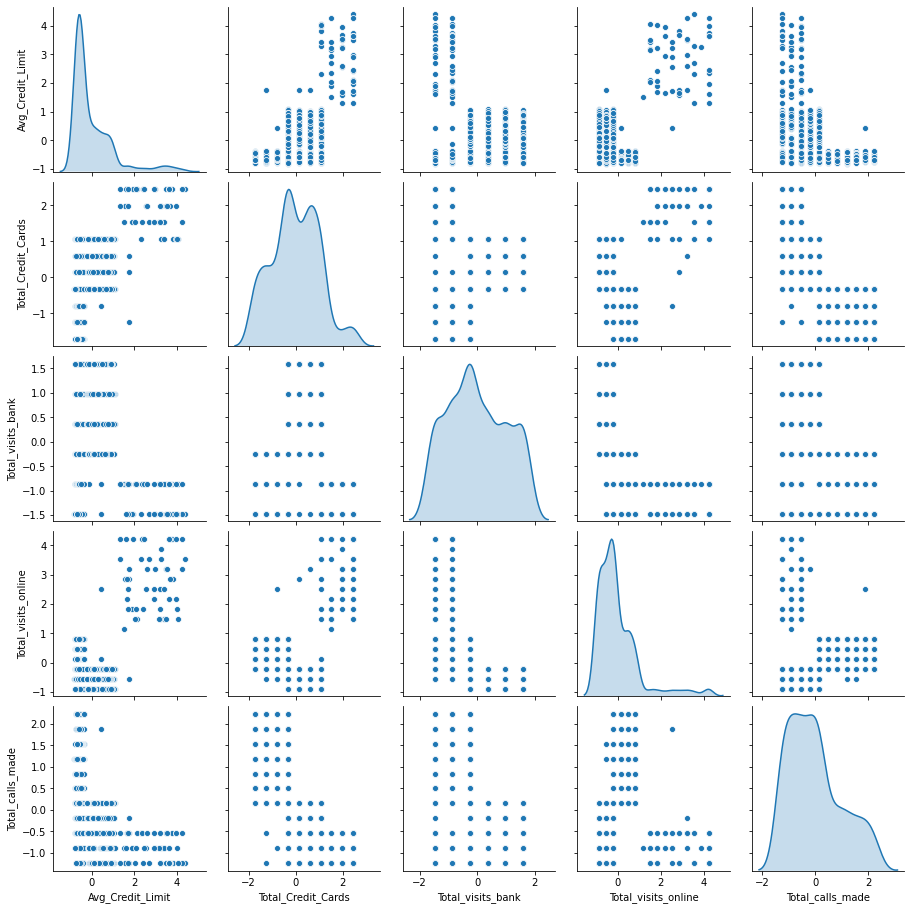

```python
sns.pairplot(df_Scaled,diag_kind='kde')
```

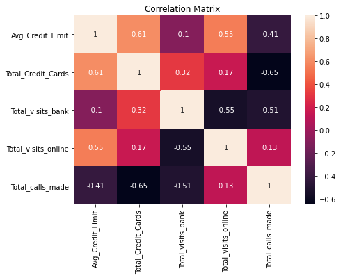

```python
plt.figure(figsize=(7,5))
sns.heatmap(df_Attr.corr(), annot=True)

plt.title('Correlation Matrix')
```

- Average Credit Limit and Total Credit Cards are highly corelated
- Average Credit Limit and Total visits online are highly corelated

## Grouping Data into similar clusters

- Trying K-Means clustering to group data based on their attributes.
- Using Elbow method to determine the optimal number of groups.

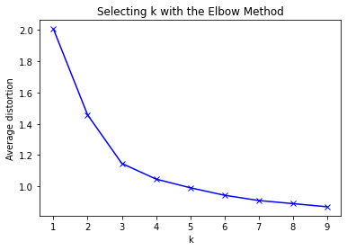

```python
from scipy.spatial.distance import cdist

clusters_range= range(1,10)
meanDistortions=[]


for clusters in clusters_range:
    model= KMeans(n_clusters= clusters,random_state=20)
    model.fit(df_Scaled)
    prediction= model.predict(df_Scaled)
    meanDistortions.append(sum(np.min(cdist(df_Scaled, model.cluster_centers_, 'euclidean'), axis=1)) / df_Scaled.shape[0])

plt.plot(clusters_range, meanDistortions, 'bx-')
plt.xlabel('k')
plt.ylabel('Average distortion')
plt.title('Selecting k with the Elbow Method')
```

- Elbow method to determine number of clusters
- Elbow can be considered to be around K=3 or K=4
- Lets take K=3 and rebuild model

```python
# Checking SilHouette Scores
from sklearn.metrics import silhouette_score
scores=[]

for clusters in range(2,11):
    model= KMeans(n_clusters= clusters,random_state=20)
    model.fit(df_Scaled)
    prediction= model.predict(df_Scaled)
    print('silhouette_score for', clusters,' cluster is :' ,silhouette_score(df_Scaled,prediction))
    scores.append(silhouette_score(df_Scaled,prediction))
```

```
silhouette_score for 2  cluster is : 0.41842496663215445
silhouette_score for 3  cluster is : 0.5157182558881063
silhouette_score for 4  cluster is : 0.3556670619372605
silhouette_score for 5  cluster is : 0.2717470361089752
silhouette_score for 6  cluster is : 0.25583657571102003
silhouette_score for 7  cluster is : 0.24817058559087743
silhouette_score for 8  cluster is : 0.227290764936125
silhouette_score for 9  cluster is : 0.22163506389073084
silhouette_score for 10  cluster is : 0.2071912637498147
```

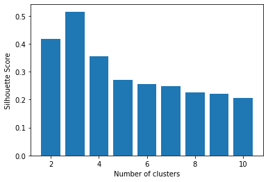

```python
# Plotting a bar graph of SilHouette Scores
Xaxis = range(2,11)
plt.bar(Xaxis,scores)
plt.xlabel('Number of clusters')
plt.ylabel('Silhouette Score')
plt.show()
```

- SilHouette Score based menthod to determine number of clusters
- SilHouette score is maximum for 3 clusters.
- Looking to calculation from Elbow , we select Cluster no 3 for which SilHouette Score is 0.51

## Using above inference, trying to bulid KMeans using K=3

```python
model= KMeans(n_clusters=3, random_state=20)
model.fit(df_Scaled)
prediction= model.predict(df_Scaled)
Silhouette_score_KMeans= silhouette_score(df_Scaled,prediction)
#Append the prediction
df_Attr['GROUP'] = prediction
df_Scaled['GROUP'] = prediction
print("Groups Assigned : \n")
df_Attr.head()
```

```
Groups Assigned :
```

|  | Avg_Credit_Limit | Total_Credit_Cards | Total_visits_bank | Total_visits_online | Total_calls_made | GROUP |
| --- | --- | --- | --- | --- | --- | --- |
| 0 | 100000 | 2 | 1 | 1 | 0 | 0 |
| 1 | 50000 | 3 | 0 | 10 | 9 | 2 |
| 2 | 50000 | 7 | 1 | 3 | 4 | 0 |
| 3 | 30000 | 5 | 1 | 1 | 4 | 0 |
| 4 | 100000 | 6 | 0 | 12 | 3 | 1 |

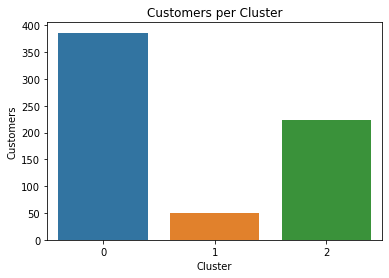

```python
# plotting cluster sizes
sns.countplot("GROUP",data=df_Attr)
plt.title ('Customers per Cluster')
plt.xlabel('Cluster')
plt.ylabel('Customers')
plt.show()
```

- There are more number of customers in Cluster 0

### Analyze the distribution of the data . One of the most informative visual tool is boxplot.

```python
df_Cluster =df_Attr.groupby(['GROUP'])
df_Cluster.mean()
```

| GROUP | Avg_Credit_Limit | Total_Credit_Cards | Total_visits_bank | Total_visits_online | Total_calls_made |
| --- | --- | --- | --- | --- | --- |
| 0 | 33782.383420 | 5.515544 | 3.489637 | 0.981865 | 2.000000 |
| 1 | 141040.000000 | 8.740000 | 0.600000 | 10.900000 | 1.080000 |
| 2 | 12174.107143 | 2.410714 | 0.933036 | 3.553571 | 6.870536 |

```
array([[<matplotlib.axes._subplots.AxesSubplot object at 0x000002456B8E01C8>,
      dtype=object)
```

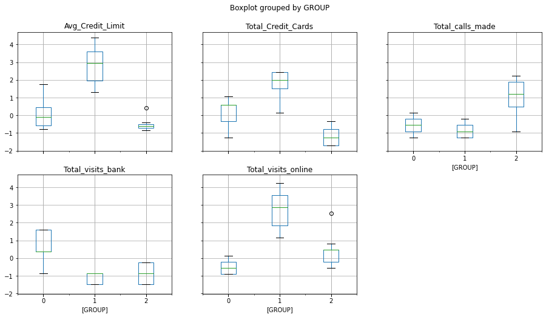

```python
df_Scaled.boxplot(by='GROUP', layout = (2,3),figsize=(15,8))
```

- Group 1 Customers have more no of credit cards
- Group 1 Customers have higher Average Credit Limit
- Group 1 Customers have more visited online

```python
# Removing GROUP Column from dataframe because this Dataframe is already having GROUPS from KMeans.

df_Attr= df_Attr.drop('GROUP', axis=1)
df_Scaled= df_Scaled.drop('GROUP', axis=1)
```

## Execute hierarchical clustering (with different linkages) with the help of dendrogram and cophenetic coeff. Analyse clusters formed using boxplot

```python
from sklearn.cluster import AgglomerativeClustering
```

```python
model= AgglomerativeClustering(n_clusters=3, affinity='euclidean',  linkage='average')
model.fit(df_Scaled)
prediction= model.fit_predict(df_Scaled)
Silhouette_score_Hierarchial_avg= silhouette_score(df_Scaled,prediction,metric='euclidean')
print('SilHouette_score for Hierarchial cluster(AVERAGE Linkage) is :' ,Silhouette_score_Hierarchial_avg)
```

```
SilHouette_score for Hierarchial cluster(AVERAGE Linkage) is : 0.515922432650965
```

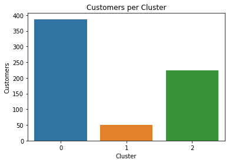

```python
# plotting cluster sizes
df_Attr['labels']= prediction
df_Scaled['labels']= prediction
sns.countplot("labels",data=df_Scaled)
plt.title ('Customers per Cluster')
plt.xlabel('Cluster')
plt.ylabel('Customers')
plt.show()
```

```python
model= AgglomerativeClustering(n_clusters=3, affinity='euclidean',  linkage='complete')
model.fit(df_Scaled)
prediction= model.fit_predict(df_Scaled)
Silhouette_score_Hierarchial_comp= silhouette_score(df_Scaled,prediction,metric='euclidean')
print('SilHouette_score for Hierarchial cluster(COMPLETE Linkage) is :' ,Silhouette_score_Hierarchial_comp)
```

```
SilHouette_score for Hierarchial cluster(COMPLETE Linkage) is : 0.5880624729711809
```

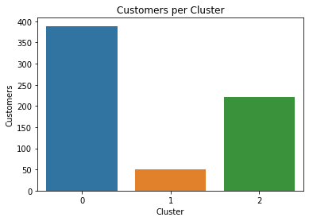

```python
# plotting cluster sizes
df_Attr['labels']= prediction
df_Scaled['labels']= prediction
sns.countplot("labels",data=df_Scaled)
plt.title ('Customers per Cluster')
plt.xlabel('Cluster')
plt.ylabel('Customers')
plt.show()
```

```python
model= AgglomerativeClustering(n_clusters=3, affinity='euclidean',  linkage='ward')
model.fit(df_Scaled)
prediction= model.fit_predict(df_Scaled)
Silhouette_score_Hierarchial_ward= silhouette_score(df_Scaled,prediction,metric='euclidean')
print('SilHouette_score for Hierarchial cluster(WARD Linkage) is :' ,Silhouette_score_Hierarchial_ward)
```

```
SilHouette_score for Hierarchial cluster(WARD Linkage) is : 0.5899658383478193
```

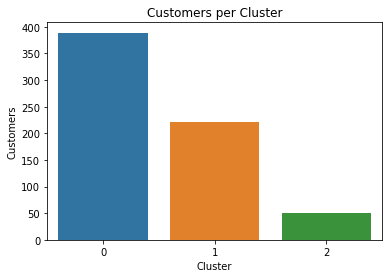

```python
# plotting cluster sizes
df_Attr['labels']= prediction
df_Scaled['labels']= prediction
sns.countplot("labels",data=df_Scaled)
plt.title ('Customers per Cluster')
plt.xlabel('Cluster')
plt.ylabel('Customers')
plt.show()
```

```python
df_Clust = df_Attr.groupby(['labels'])
```

```python
df_Clust.mean()
```

| labels | Avg_Credit_Limit | Total_Credit_Cards | Total_visits_bank | Total_visits_online | Total_calls_made |
| --- | --- | --- | --- | --- | --- |
| 0 | 33591.25964 | 5.496144 | 3.467866 | 0.987147 | 2.002571 |
| 1 | 12217.19457 | 2.402715 | 0.936652 | 3.579186 | 6.932127 |
| 2 | 141040.00000 | 8.740000 | 0.600000 | 10.900000 | 1.080000 |

```
array([[<matplotlib.axes._subplots.AxesSubplot object at 0x000002456CFA0408>,
      dtype=object)
```

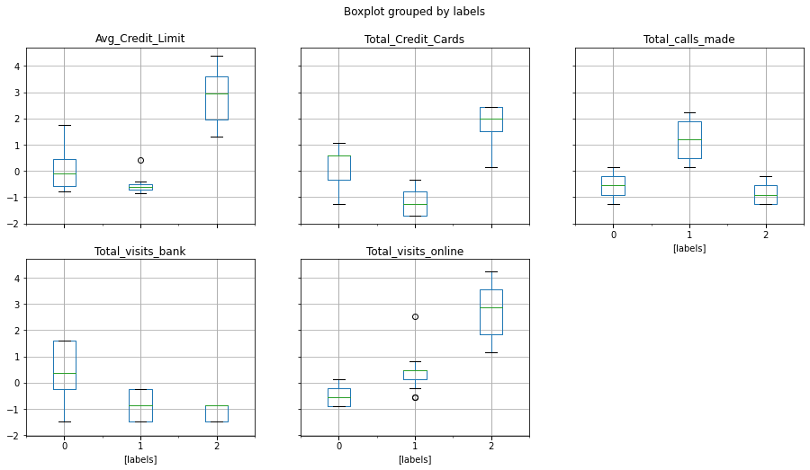

```python
df_Scaled.boxplot(by='labels', layout = (2,3),figsize=(15,8))
```

- Average Credit limit is more for Cluster 2 customers
- CLuster 2 cutomers have more no of Credit cards and they visit Bank website Frequently.

```python
from scipy.cluster.hierarchy import cophenet, dendrogram, linkage
```

```python
from scipy.spatial.distance import pdist  #Pairwise distribution between data points
```

```python
# cophenet index is a measure of the correlation between the distance of points in feature space and distance on dendrogram
# closer it is to 1, the better is the clustering

Z = linkage(df_Scaled, metric='euclidean', method='average')
c_Avg, coph_dists = cophenet(Z , pdist(df_Scaled))

c_Avg
```

```
0.9169639368223772
```

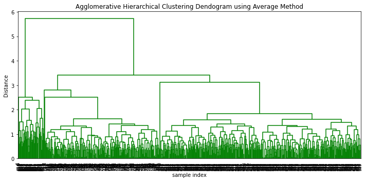

```python
plt.figure(figsize=(10, 5))
plt.title('Agglomerative Hierarchical Clustering Dendogram using Average Method')
plt.xlabel('sample index')
plt.ylabel('Distance')
dendrogram(Z, leaf_rotation=90.,color_threshold = 40, leaf_font_size=8. )
plt.tight_layout()
```

```python
# cophenet index is a measure of the correlation between the distance of points in feature space and distance on dendrogram
# closer it is to 1, the better is the clustering

Z = linkage(df_Scaled, metric='euclidean', method='complete')
c_Comp, coph_dists = cophenet(Z , pdist(df_Scaled))

c_Comp
```

```
0.9003320467245792
```

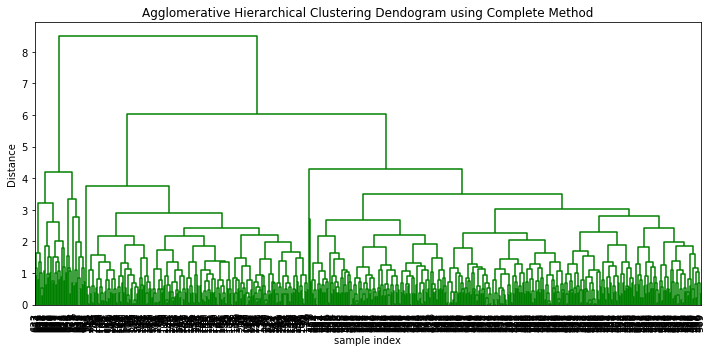

```python
plt.figure(figsize=(10, 5))
plt.title('Agglomerative Hierarchical Clustering Dendogram using Complete Method')
plt.xlabel('sample index')
plt.ylabel('Distance')
dendrogram(Z, leaf_rotation=90.,color_threshold=90,  leaf_font_size=10. )
plt.tight_layout()
```

```python
# cophenet index is a measure of the correlation between the distance of points in feature space and distance on dendrogram
# closer it is to 1, the better is the clustering

Z = linkage(df_Scaled, metric='euclidean', method='ward')
c_Ward, coph_dists = cophenet(Z , pdist(df_Scaled))

c_Ward
```

```
0.7741813492750527
```

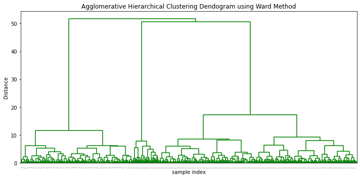

```python
plt.figure(figsize=(10, 5))
plt.title('Agglomerative Hierarchical Clustering Dendogram using Ward Method')
plt.xlabel('sample index')
plt.ylabel('Distance')
dendrogram(Z, leaf_rotation=90.,color_threshold=90,  leaf_font_size=1. )
plt.tight_layout()
```

# Comparing SilHouette Scores

```python
print('SilHouette_score for KMeans is                               :' ,Silhouette_score_KMeans)
print('SilHouette_score for Hierarchial cluster(AVERAGE METHOD) is  :' ,Silhouette_score_Hierarchial_avg)
print('SilHouette_score for Hierarchial cluster(COMPLETE METHOD) is :' ,Silhouette_score_Hierarchial_comp)
print('SilHouette_score for Hierarchial cluster(WARD METHOD) is     :' ,Silhouette_score_Hierarchial_ward)
```

```
SilHouette_score for KMeans is                               : 0.5157182558881063
SilHouette_score for Hierarchial cluster(AVERAGE METHOD) is  : 0.515922432650965
SilHouette_score for Hierarchial cluster(COMPLETE METHOD) is : 0.5880624729711809
SilHouette_score for Hierarchial cluster(WARD METHOD) is     : 0.5899658383478193
```

```python
print('Cophenet index for Average Linkage  :' ,c_Avg)
print('Cophenet index for Complete Linkage :' ,c_Comp)
print('Cophenet index for Ward Linkage     :' ,c_Ward)
```

```
Cophenet index for Average Linkage  : 0.9169639368223772
Cophenet index for Complete Linkage : 0.9003320467245792
Cophenet index for Ward Linkage     : 0.7741813492750527
```

# Final Cluster Model

```python
df_Scaled.drop(columns='labels', inplace=True)
```

```python
model= AgglomerativeClustering(n_clusters=3, affinity='euclidean',  linkage='complete')
model.fit(df_Scaled)
prediction= model.fit_predict(df_Scaled)
Silhouette_score_Hierarchial_comp= silhouette_score(df_Scaled,prediction,metric='euclidean')
```

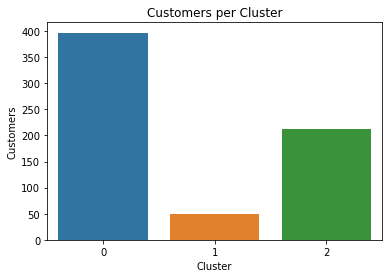

```python
# plotting cluster sizes
df_Attr['labels']= prediction
df_Scaled['labels']= prediction
sns.countplot("labels",data=df_Scaled)
plt.title ('Customers per Cluster')
plt.xlabel('Cluster')
plt.ylabel('Customers')
plt.show()
```

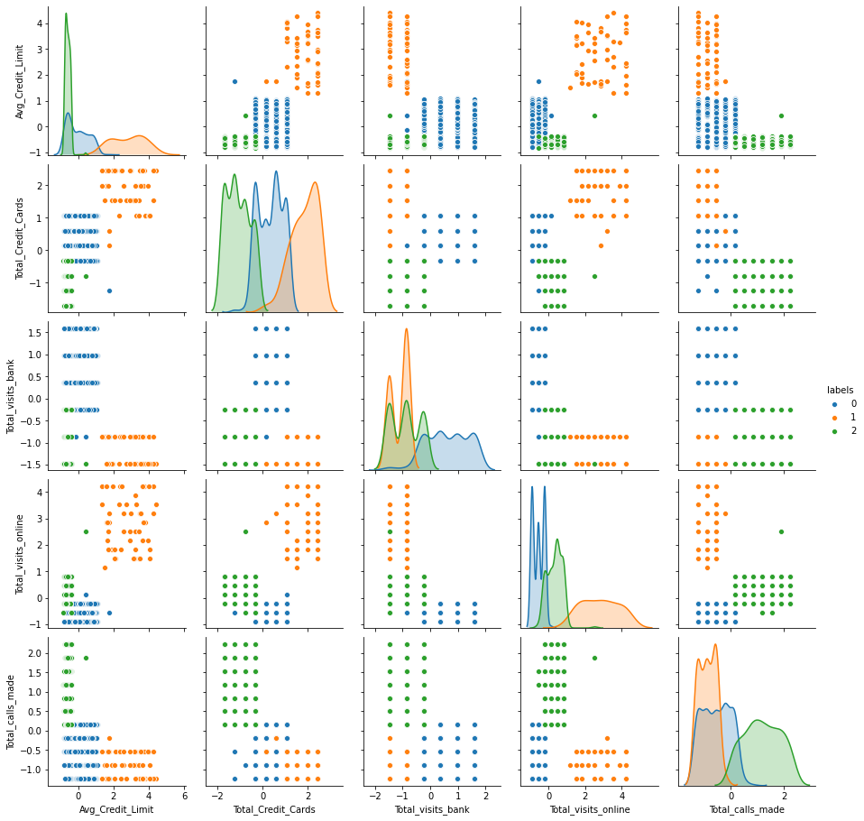

```python
# Pairplot of CLusters
sns.pairplot(df_Scaled,diag_kind='kde', hue='labels')
```

```
array([[<matplotlib.axes._subplots.AxesSubplot object at 0x000002456FCCDA48>,
      dtype=object)
```

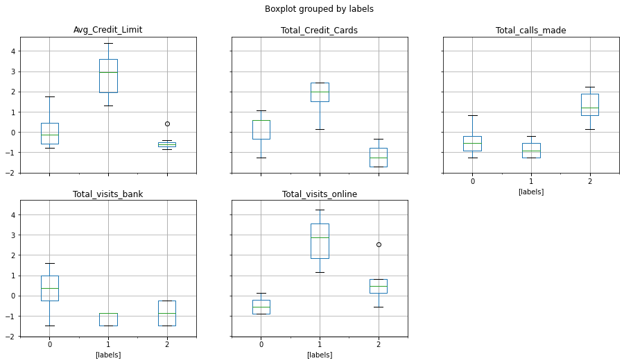

```python
df_Scaled.boxplot(by='labels', layout = (2,3),figsize=(15,8))
```

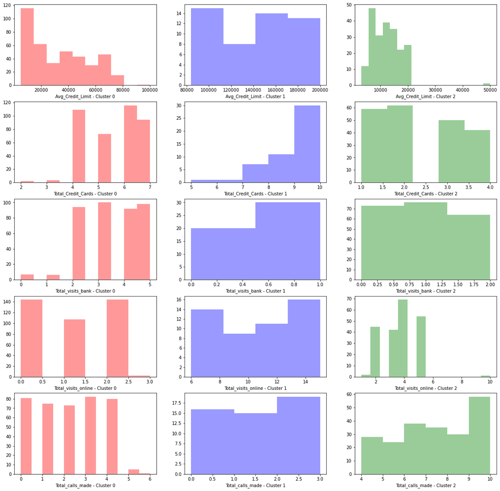

```python
x_cor=range(0,5)        # range of X co-ordinate [0,1,2,3,4]
y_cor=range(0,3)        # range of Y co-ordinate [0,1,2]
cols = ['Avg_Credit_Limit', 'Total_Credit_Cards', 'Total_visits_bank','Total_visits_online', 'Total_calls_made']
color=['r', 'b', 'g']
a=0
fig,ax=plt.subplots(5,3,figsize=(20,20))
for i in x_cor:
    s=0                             # This variable is used to increment cluster/ label number
    for j in y_cor:
        col=cols[a]
        clr=color[s]
        cluster=df_Attr[df_Attr['labels']==s]
        sns.distplot(cluster[col],color=clr,ax=ax[i][j],kde=False, axlabel=('{} {} {}'.format(col,'- Cluster', j)))
        s=s+1
    a=a+1
```

# Cluster Analysis

- There are three clusters formed
- Number of Customers in Cluster 0 : 397, Cluster 1 : 50, Cluster 2 : 213
- Cluster 1 customers are having high Average Credit Limit
- Cluster 1 customers are having more number of Credit cards
- Looking to Cluster 1 Customers Credit Limit and holding Credit card numbers, we can infer that they are from segement whose expenditure are high.
- Bank should Target to increase customers in Cluster 1
- Bank should target to check if there is potential issue in Cluster 0, 2 to increase their Credit Limit